# Final_Project_Miko

Miko

2022-12-06

```r
library(ggplot2)
library(ezids)
library(dplyr)
library(readr)
library(tidyr)
library(knitr)
library(magrittr)
```

```r
xkablesummary(subset(DF,select=c(Arrest.Year, Arrest.Hour, Age)))
```

Table: Statistics summary.

|  | Arrest.Year | Arrest.Hour | Age |
| --- | --- | --- | --- |
| Min | Min. :2016 | Min. : 0.0 | Min. : 18.0 |
| Q1 | 1st Qu.:2017 | 1st Qu.: 6.0 | 1st Qu.: 25.0 |
| Median | Median :2018 | Median :12.0 | Median : 32.0 |
| Mean | Mean :2018 | Mean :11.8 | Mean : 35.2 |
| Q3 | 3rd Qu.:2019 | 3rd Qu.:18.0 | 3rd Qu.: 43.0 |
| Max | Max. :2021 | Max. :23.0 | Max. :121.0 |

### Missing Values

##### Our variables of concern in thsi dataset contain rich data.. over 95% of data available in each useful column.. will not delete any rows

```r
#get month and day variables.. might be interesting, who knows?
DF <- separate(DF, col = Arrest_Date, into = c("Year","Month","Day"), sep = "-", remove = FALSE, fill="left")
#remove the new year column formed, it is redundant.. we already have Year column
DF = DF[,-4]
colnames(DF)
```

```
##  [1] "Arrestee_Type"             "Arrest_Year"
##  [3] "Arrest_Date"               "Month"
##  [5] "Day"                       "Arrest_Hour"
##  [7] "Age"                       "Defendant_PSA"
##  [9] "Defendant_District"        "Defendant_Race"
## [11] "Defendant_Ethnicity"       "Defendant_Sex"
## [13] "Arrest_Category"           "Charge_Description"
## [15] "Arrest_Location_District"  "Offense_Location_District"
```

### Correct inconsistent values

`Arrest_Category` had some different values for 2021 and other years:

- Data in 2021 had “Release Violations/Fugitive (Fug)” and “Release Violations/Fugitive (Warr)” although data in other years have “Release Violations/Fugitive” instead of them.
- Data in 2021 had “Fraud and Financial Crimes (Frau)” although data in other years have “Fraud and Financial Crimes”.

Therefore, we coverted these values in 2021 into the correspond values in other years.

## Remove Unnecessary Rows

##Model

There are two fields in the data which provide the description of the crime incident. The first, primary description provides a broad category of the crime type and the second provides more detailed information about the first. We use the primary description to categorize different crime types.

The data contains 30 crime types; not all of which are mutually exclusive. We can combine two or more similar categories into one to reduce this number and make the analysis a bit more manageable.

```
## # A tibble: 10 × 2
##    crime      count
##    <fct>      <int>
##  1 ASSAULT    44146
##  2 VIOLENT    34409
##  3 TRAFFIC    19989
##  4 NONVIOLENT 13291
##  5 DRUG       12825
##  6 OTHERS     12178
##  7 THEFT      10826
##  8 SEX         3984
##  9 FRAUD        671
## 10 <NA>          12
```

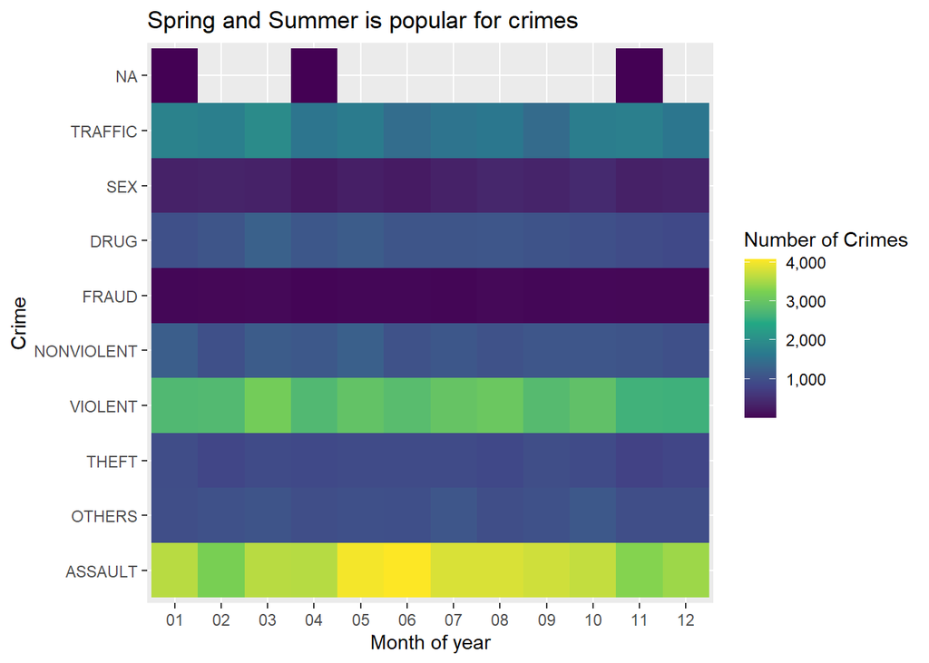

A quick look at the heat map shows that most of crime happens at the spring and summer.

```
## # A tibble: 16,768 × 3
## # Groups:   crime [10]
##    crime      Arrest_Date count
##    <fct>      <date>      <int>
##  1 ASSAULT    2020-06-01    274
##  2 NONVIOLENT 2017-01-20    234
##  3 ASSAULT    2021-01-06     65
##  4 VIOLENT    2017-08-23     47
##  5 ASSAULT    2016-01-01     46
##  6 ASSAULT    2016-10-30     45
##  7 VIOLENT    2016-04-21     44
##  8 ASSAULT    2017-01-01     42
##  9 ASSAULT    2016-06-25     41
## 10 ASSAULT    2017-04-29     41
## # … with 16,758 more rows
```

By ordering this, we can see from all the data, assault happens a lot times at 2020-06-01 and also nonviolent happens much higher at 2017-01-20 than the other dates.

```
## # A tibble: 2,192 × 1
##    Arrest_Date
##    <date>
##  1 2016-01-01
##  2 2016-01-02
##  3 2016-01-03
##  4 2016-01-04
##  5 2016-01-05
##  6 2016-01-06
##  7 2016-01-07
##  8 2016-01-08
##  9 2016-01-09
## 10 2016-01-10
## # … with 2,182 more rows
```

```
## # A tibble: 4 × 2
##   crime_type count
##   <fct>      <int>
## 1 <NA>          12
## 2 OTHERS     12178
## 3 NONVIOLENT 57602
## 4 VIOLENT    82539
```

Violent crime is far more than nonviolent crime.

####Class by seasons

Our visualization exercise showed that there is considerable variation in crime incidents with respect to the time of the year. To use the month variable effectively, we can combine the similar months to form a new variable that reflects the changes in crime incidents with seasons.

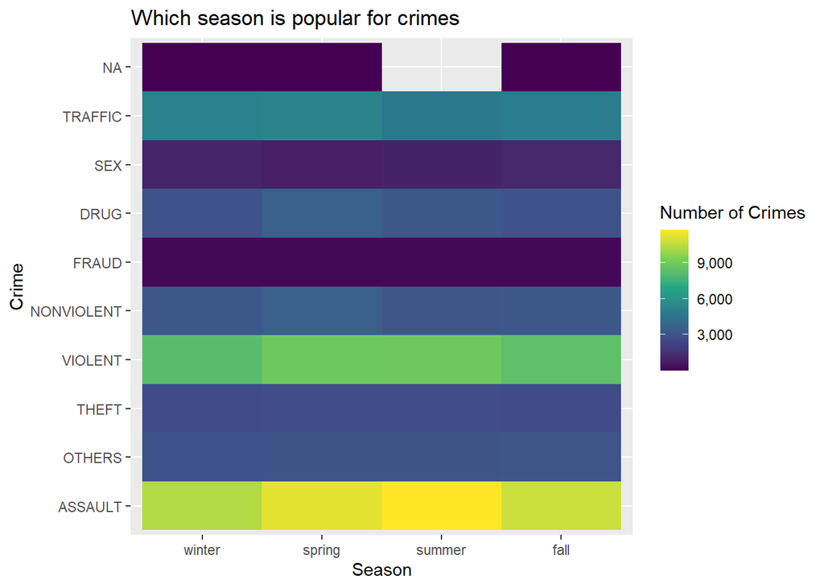

```r
model_data %>%
  group_by(crime,season) %>%
  summarise(count=n()) %>%
  ggplot(aes(x=crime, y=season)) +
  geom_tile(aes(fill=count)) +
  labs(x="Crime", y = "Season", title="Which season is popular for crimes") +
  scale_fill_viridis_c("Number of Crimes",label=comma) +
  coord_flip()
```

This chart is more clear than the month chart that summer has the most crime.